# MOR Health Analysis: Examining MOUD Reciept and Incaraceration Statistics

**Biostatistician:** Licza Lobo, Jacob Parquet

**Principal Investigator:** Ali Jalai, PhD; Mila Sun, PhD; Caroline Andy

*July 17, 2026*

# Study Background Information

Individuals with opioid use disorder are at high risk of adverse healthcare outcomes and overdose upon jail release. Incarceration increases overdose risk due to reduced opioid tolerance, interrupted social support, and limited access to treatment during confinement. Medication for opioid use disorder (MOUD) offered during incarceration may mitigate this risk: a 2025 study of individuals released from Massachusetts county jails found that receipt of MOUD in jail was associated with a greater likelihood of postrelease MOUD initiation, along with a 52% lower risk of fatal opioid overdose, a 24% lower risk of non-fatal opioid overdose, a 56% lower risk of death from any cause, and a 12% lower risk of reincarceration after release. Provision of MOUD during incarceration has also been associated with decreased emergency department visits, increased MOUD uptake, and increased Medicaid outpatient and pharmacy claims post-release from prison.

# Aims

Explore the association between medication for opioid use disorder upon jail release and time to the next incarceration event. Examine whether providing medication for opioid use disorder upon jail release reduces acute care (emergency department and inpatient visit) cost within the month following release.

# Results

## Table 1

### Demographics by MOUD Treatment at Index

| **Characteristic** | **Overall** N = 28,214<sup>1</sup> | **No MOUD** N = 23,636<sup>1</sup> | **MOUD** N = 4,578<sup>1</sup> |
| --- | --- | --- | --- |
| Age at Discharge | 40.63 (11.54) | 40.15 (11.72) | 43.16 (10.24) |
| Race |  |  |  |
| Black | 10,463 (38%) | 9,062 (39%) | 1,401 (31%) |
| White | 8,370 (30%) | 6,744 (29%) | 1,626 (36%) |
| Asian or PI | 181 (0.6%) | 166 (0.7%) | 15 (0.3%) |
| AI/NA/Other | 8,838 (32%) | 7,375 (32%) | 1,463 (32%) |
| Missing | 362 | 289 | 73 |
| Ethnicity (Hispanic) |  |  |  |
| No | 16,309 (58%) | 13,749 (58%) | 2,560 (56%) |
| Yes | 11,905 (42%) | 9,887 (42%) | 2,018 (44%) |
| Homeless Status |  |  |  |
| No | 24,888 (88%) | 20,982 (89%) | 3,906 (85%) |
| Yes | 3,326 (12%) | 2,654 (11%) | 672 (15%) |
| Smoking Status |  |  |  |
| No | 5,521 (20%) | 4,846 (21%) | 675 (15%) |
| Yes | 21,471 (80%) | 17,710 (79%) | 3,761 (85%) |
| Missing | 1,222 | 1,080 | 142 |
| Marital Status |  |  |  |
| Single/Never Married | 22,001 (78%) | 18,508 (79%) | 3,493 (76%) |
| Married/Partner | 4,762 (17%) | 3,959 (17%) | 803 (18%) |
| Divorced/Separated/Widowed | 1,371 (4.9%) | 1,099 (4.7%) | 272 (6.0%) |
| Missing | 80 | 70 | 10 |
| Education Level |  |  |  |
| <HS | 12,070 (45%) | 10,080 (45%) | 1,990 (45%) |
| HS | 9,519 (35%) | 7,922 (35%) | 1,597 (36%) |
| >= Some College | 5,352 (20%) | 4,512 (20%) | 840 (19%) |
| Missing | 1,273 | 1,122 | 151 |

<sup>1</sup> Mean (SD); n (%)

### Incarceration Characteristics by MOUD Treatment (All Events)

| **Characteristic** | **Overall** N = 68,692<sup>1</sup> | **No MOUD** N = 52,172<sup>1</sup> | **MOUD** N = 16,520<sup>1</sup> |
| --- | --- | --- | --- |
| Total Time Served (months) | 6.72 (7.81) | 6.33 (7.59) | 7.95 (8.32) |
| Event Specific Time Sevrved (months) | 1.30 (2.29) | 1.26 (2.38) | 1.44 (1.97) |
| Time Free (months) | 19.34 (21.57) | 20.82 (22.03) | 14.70 (19.30) |
| Final Charge |  |  |  |
| Felony | 28,989 (42%) | 24,778 (47%) | 4,211 (25%) |
| Misdemeanor | 35,794 (52%) | 23,910 (46%) | 11,884 (72%) |
| Other | 3,909 (5.7%) | 3,484 (6.7%) | 425 (2.6%) |
| Final Parole Violation |  |  |  |
| No | 65,490 (95%) | 49,402 (95%) | 16,088 (97%) |
| Yes | 3,202 (4.7%) | 2,770 (5.3%) | 432 (2.6%) |
| OUD Type |  |  |  |
| Weak OUD | 4,667 (6.8%) | 4,667 (8.9%) | 0 (0%) |
| Confirmed OUD | 64,025 (93%) | 47,505 (91%) | 16,520 (100%) |
| Treatment Program Before Incarceration |  |  |  |
| No | 48,237 (70%) | 40,190 (77%) | 8,047 (49%) |
| Yes | 20,455 (30%) | 11,982 (23%) | 8,473 (51%) |

<sup>1</sup> Mean (SD); n (%)

### Demographics by MOUD Treatment Switching

| **Characteristic** | **Overall** N = 28,214<sup>1</sup> | **Always Get MOUD** N = 2,483<sup>1</sup> | **Never Get MOUD** N = 19,948<sup>1</sup> | **Switches** N = 5,783<sup>1</sup> |
| --- | --- | --- | --- | --- |
| Age at Discharge | 40.63 (11.54) | 44.31 (10.50) | 40.16 (11.97) | 40.69 (10.12) |
| Race |  |  |  |  |
| Black | 10,463 (38%) | 724 (30%) | 7,922 (40%) | 1,817 (32%) |
| White | 8,370 (30%) | 906 (37%) | 5,437 (28%) | 2,027 (36%) |
| Asian or PI | 181 (0.6%) | 7 (0.3%) | 154 (0.8%) | 20 (0.4%) |
| AI/NA/Other | 8,838 (32%) | 808 (33%) | 6,203 (31%) | 1,827 (32%) |
| Missing | 362 | 38 | 232 | 92 |
| Ethnicity (Hispanic) |  |  |  |  |
| No | 16,309 (58%) | 1,378 (55%) | 11,690 (59%) | 3,241 (56%) |
| Yes | 11,905 (42%) | 1,105 (45%) | 8,258 (41%) | 2,542 (44%) |
| Homeless Status |  |  |  |  |
| No | 24,888 (88%) | 2,109 (85%) | 17,723 (89%) | 5,056 (87%) |
| Yes | 3,326 (12%) | 374 (15%) | 2,225 (11%) | 727 (13%) |
| Smoking Status |  |  |  |  |
| No | 5,521 (20%) | 381 (16%) | 4,353 (23%) | 787 (14%) |
| Yes | 21,471 (80%) | 2,019 (84%) | 14,739 (77%) | 4,713 (86%) |
| Missing | 1,222 | 83 | 856 | 283 |
| Marital Status |  |  |  |  |
| Single/Never Married | 22,001 (78%) | 1,858 (75%) | 15,616 (79%) | 4,527 (79%) |
| Married/Partner | 4,762 (17%) | 455 (18%) | 3,346 (17%) | 961 (17%) |
| Divorced/Separated/Widowed | 1,371 (4.9%) | 165 (6.7%) | 928 (4.7%) | 278 (4.8%) |
| Missing | 80 | 5 | 58 | 17 |
| Education Level |  |  |  |  |
| <HS | 12,070 (45%) | 1,056 (44%) | 8,479 (44%) | 2,535 (46%) |
| HS | 9,519 (35%) | 844 (35%) | 6,679 (35%) | 1,996 (36%) |
| >= Some College | 5,352 (20%) | 497 (21%) | 3,900 (20%) | 955 (17%) |
| Missing | 1,273 | 86 | 890 | 297 |

<sup>1</sup> Mean (SD); n (%)

### Incarceration Statistics

Incarceration Descriptive Statistics

|  | Reincarceration |
| --- | --- |
| Total Participants | 28214 |
| Ever Reincarcerated n (%) | 13634 (48.3%) |
| Number of Reincarcerations - Mean (SD) | 1.43 (2.67) |
| Number of Reincarcerations - Median [IQR] | 0 [0-2] |
| 0 Reincarcerations n (%) | 14580 (51.7%) |
| 1 Reincarceration n (%) | 5603 (19.9%) |
| 2 Reincarcerations n (%) | 2918 (10.3%) |
| 3+ Reincarcerations n (%) | 5113 (18.1%) |
| Treatment Switch n (%) - among reincarcerated | 5783 (42.4%) |
| Number of Treatment Switches - Mean (SD) - among switchers | 2.03 (1.73) |
| Number of Treatment Switches - Median [IQR] - among switchers | 1 [1-2] |

## MOUD Treatment Analysis

### Unadjusted Kaplan Meier Curve and Hazard Ratios (Pre Propensity Score Matching)

#### Kaplan Meier Curve

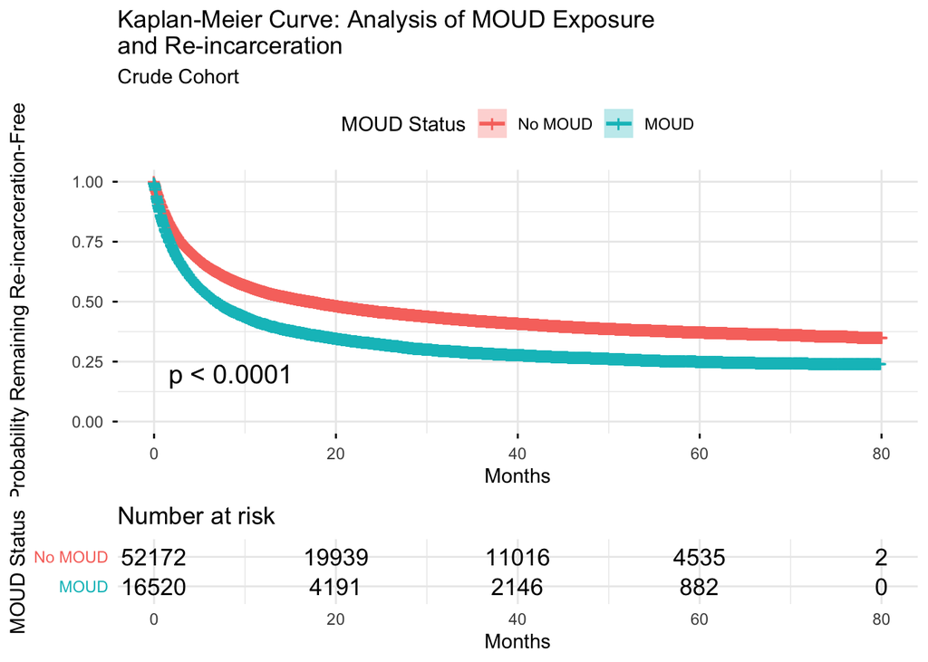

#### Linear Model

Unadjusted Crude Analysis: Association Between MOUD Exposure and Time Until Next Incarceration (Linear Model)

| Term | Estimate | Standard Error | t-statistic | P-value | 95% CI Lower | 95% CI Upper |
| --- | --- | --- | --- | --- | --- | --- |
| Intercept | 20.816 | 0.094 | 222.101 | 0 | 20.633 | 21.000 |
| MOUD (vs No MOUD) | -6.119 | 0.191 | -32.018 | 0 | -6.494 | -5.745 |

#### Hazard Ratio

Unadjusted Crude Analysis: Association Between MOUD Exposure and Time to Subsequent Re-incarceration (Cox Regression)

| Comparison | Hazard Ratio | SE | z-statistic | P-value | 95% CI Lower | 95% CI Upper |
| --- | --- | --- | --- | --- | --- | --- |
| MOUD (vs No MOUD) | 1.443 | 0.011 | 32.788 | 0 | 1.412 | 1.475 |

### Time to Reincarceration by MOUD receipt (No MOUD vs MOUD): Propensity Score Matching

#### Kaplan Meier Curve

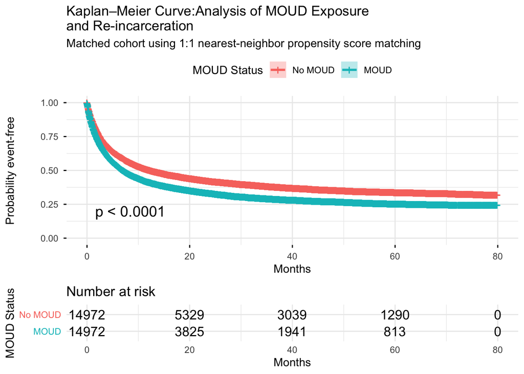

#### Linear Model: GEE

Adjusted Propensity Scored Matched Analysis: Association Between MOUD Exposure and Time Until Next Incarceration (GEE Model)

| Term | Estimate | Standard Error | Wald Statistic | P-value | 95% CI Lower | 95% CI Upper |
| --- | --- | --- | --- | --- | --- | --- |
| Intercept | 19.863 | 0.180 | 12114.841 | 0 | 19.509 | 20.216 |
| MOUD (vs No MOUD) | -5.027 | 0.238 | 444.493 | 0 | -5.495 | -4.560 |

#### Hazard Ratio

Adjusted Matched Analysis: Association Between MOUD Exposure and Time to Subsequent Re-incarceration (Cox Regression)

| Comparison | Hazard Ratio | Robust SE | robust.se | z-statistic | P-value | 95% CI Lower | 95% CI Upper |
| --- | --- | --- | --- | --- | --- | --- | --- |
| MOUD (vs No MOUD) | 1.277 | 0.015 | 0.016 | 15.303 | 0 | 1.238 | 1.318 |

#### Matching Statistics

Covariate Balance Before and After 1:1 Propensity Score Matching: MOUD vs No MOUD

| Covariate | Unmatched SMD | Matched SMD |
| --- | --- | --- |
| distance | 0.834 | 0.049 |
| finalcharge_Felony | -0.237 | 0.009 |
| finalcharge_Misdemeanor | 0.270 | -0.009 |
| finalcharge_Other | -0.033 | 0.000 |
| finalpv_Yes | -0.029 | 0.000 |
| bradh_Yes | 0.044 | 0.023 |
| age_dis | 0.189 | -0.010 |
| race_new_Black | -0.063 | -0.011 |
| race_new_White | 0.070 | 0.009 |
| race_new_Asian or PI | -0.003 | 0.000 |
| race_new_AI/NA/Other | -0.003 | 0.001 |
| hispanic_Yes | 0.006 | 0.000 |
| homeless_Yes | 0.047 | 0.005 |
| currsmoker_Yes | 0.046 | 0.001 |
| marstatus_new_Single/Never Married | -0.006 | 0.002 |
| marstatus_new_Married/Partner | 0.001 | -0.001 |
| marstatus_new_Divorced/Separated/Widowed | 0.004 | -0.001 |
| educlevel_new_<HS | -0.003 | 0.004 |
| educlevel_new_HS | 0.014 | -0.004 |
| educlevel_new_>= Some College | -0.011 | 0.000 |
| personality_mhdx_Yes | -0.003 | 0.008 |
| neurocog_mhdx_Yes | 0.000 | 0.000 |
| ptsd_trauma_stress_mhdx_Yes | 0.026 | 0.007 |
| depress_mhdx_Yes | 0.034 | 0.011 |
| bipolar_mhdx_Yes | 0.008 | 0.003 |
| schizoph_psychotic_mhdx_Yes | -0.017 | 0.000 |
| total_prior_incarc_months | 0.026 | 0.011 |
| txprogbeforeincarc_Yes | 0.274 | 0.021 |
| violent_or_afel_new_Yes | -0.083 | 0.006 |
| cocdx.new_Yes | 0.092 | 0.015 |
| alcdx.new_Yes | 0.025 | 0.004 |

#### Jitter Plot

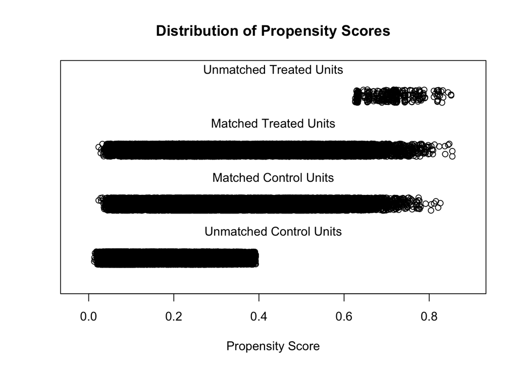